# Lecture 8: Errorbar plots

27 October 2017

# 1 Housekeeping

Remember that `rm(list=ls())` is not sufficient for a full clean set up of R, and you should use `Ctrl/Cmd-SHIFT-F10` in Rstudio to Restart R cleanly and check that this works at least at the end of your analysis, or periodically during development.

```r
# remove (almost) all objects currently held in the R environment
rm(list=ls())
```

# 2 Errorbar plot

We will continue to use the `iris` dataset, and follow on directly from the previous lecture on barplots to visualise the same data using errorbar plots.

Use an errorbar plot to show the data

```r
# specify a 1x1 panel plot
par(mfrow=c(1,1))
```

Calculate the means of the groups using tapply()

```r
mu <- tapply(iris$Petal.Length, iris$Species, mean)
```

Here I write my own function to calculate the 95% confidence intervals, see

[WIKIPEDIA](https://en.wikipedia.org/wiki/Standard_error#Assumptions_and_usage)

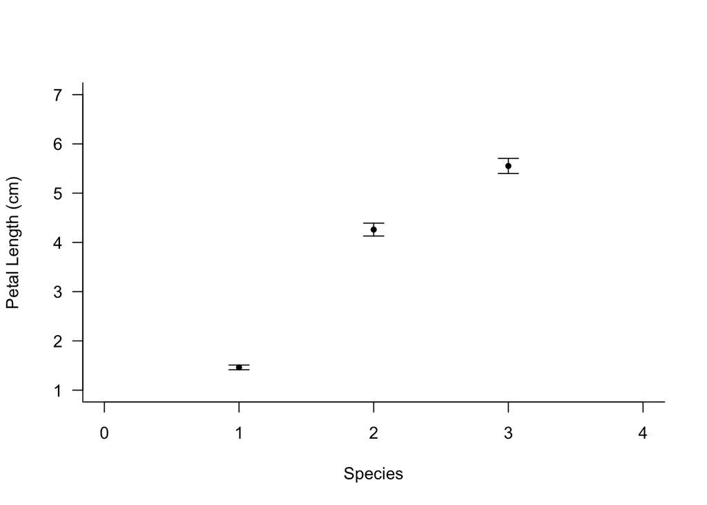

```r
CI95 <- function (x) {return( 1.96 * sqrt( var(x) / length(x) ) )}

# calculate the error for ecah group (espilon or eps as named)
eps <- tapply(iris$Petal.Length,iris$Species,CI95)

plot(1:3,mu,xlim=c(0,4),ylim=c(1,7),pch=20, las=1, bty="L",
      xlab="Species", ylab="Petal Length (cm)")

arrows( x0 = 1:3, x1 = 1:3,
        y0 = mu + eps, y1 = mu - eps,
        code = 3, length = 0.1, angle = 90)
```

## 2.1 Fix the x-axis labels and tidy up the plot

```r
par(mfrow=c(1,1))
```

Calculate the means of the groups

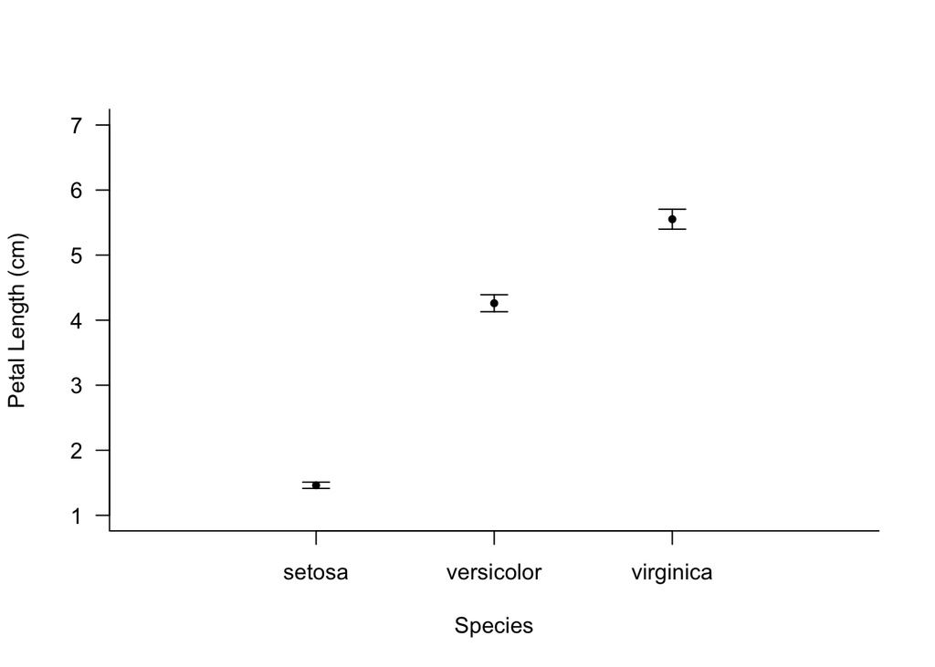

```r
# mu <- tapply(iris$Petal.Length,iris$Species,mean)
#
# CI95 <- function (x) {return(1.96*sd(x)/sqrt(length(x)))}
#
# se <- tapply(iris$Petal.Length,iris$Species,CI95)

plot(1:3, mu, xlim = c(0,4), ylim = c(1,7),
     pch = 20, las = 1, bty = "L", xaxt ="n",
     xlab = "Species", ylab = "Petal Length (cm)")

axis(1, at = 1:3, levels(iris$Species))

arrows( x0 = 1:3, x1 = 1:3,
        y0 = mu + eps, y1 = mu - eps,
        code = 3, length = 0.1, angle = 90)
```

## 2.2 Axis function description

axis(side, at=, labels=, pos=, lty=, col=, las=, tck=, …)

Side option in axis function - an integer indicating the side of the graph to draw the axis (1=bottom, 2=left, 3=top, 4=right) At - a numeric vector indicating where tic marks should be drawn

# 3 Errorbars in ggplot

Do not forget to install ggplot package before executing this code.

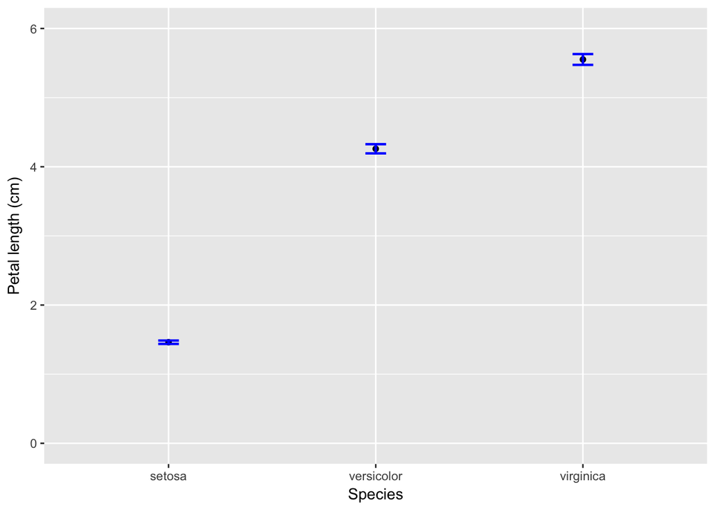

```r
library(tidyverse) # load package with ggplot
p1 <- ggplot(iris, aes(Species, Petal.Length)) +
  stat_summary(fun.y = mean, geom = "point") +
  coord_cartesian(ylim = c(0, 6)) + labs(y = "Petal length (cm)") +
  stat_summary(fun.data = mean_se, geom = "errorbar",
               width = 0.1, size = 0.8, colour = "blue")

print(p1)
```